# Heterogeneous Treatment Effects

Shikhar Singh

September 30, 2026

# Agenda

### 1. Detecting Heterogeneity

### 2. Treatment-Covariate Interactions

### 3. Treatment-Treatment Interactions

### 4. Multiple Comparisons Bias

# Heterogeneity

**Concept:** This class focuses on the *variability in treatment effects* or $Var[\tau_i]$. I will begin with a discussion on how to detect heterogeneous treatment effects. Mainly, we either place bounds on $Var[\tau_i]$, or do a hypothesis test ($\widehat{Var[Y_i(1)]} = \widehat{Var[Y_i(0)]}$) under the constant effects assumption. After this, I will show some regression-based strategies to model heterogeneity: first when there is interaction between treatment and covariates; and then between treatments.

# Detecting Heterogeneity

## Bounds on $Var[\tau_i]$

**Intuition:** We can never point-estimate $Var[\tau_i]$ because $Cov[Y_i(1),Y_i(0)]$ is never known due to the fundamental problem of causal inference. However, we can place bounds on this quantity by estimating the minimum and maximum covariance between treated and untreated potential outcomes.

To see this, note that:

$$\begin{equation}
Var[\tau_i] = Var[Y_i(1) - Y_i(0)] = Var[Y_i(1)] + Var[Y_i(0)] - 2\cdot
Cov[Y_i(1),Y_i(0)]
\end{equation}$$

We can use the observations in the treatment group to get $\widehat{Var[Y_i(1)]}$; and similarly use the control group units to get $\widehat{Var[Y_i(0)]}$. This leaves the covariance term.

Analytically, we know from the Cauchy-Schwartz inequality that for any two random variables $X$ and $Y$:

$$\begin{equation}
|cov(X,Y)| \leq \sqrt{Var(X) \cdot Var(Y)}
\end{equation}$$

Assuming $X = Y_i(1)$ and $Y = Y_i(0)$, this means:

$$\begin{equation}
-\sqrt{Var(X) \cdot Var(Y)} \leq cov(X,Y) \leq \sqrt{Var(X) \cdot
Var(Y)}
\end{equation}$$

In words, the maximum value of the covariance is $\sqrt{Var(X) \cdot Var(Y)}$ and minimum value is $-\sqrt{Var(X) \cdot Var(Y)}$.

You’ll note that the Cauchy-Schwartz inequality provides bounds on the covariance term mainly using the variances of the two potential outcomes (second moment of the distributions). However, in an experiment, our treatment and control groups are a random subset of the population. This means each group provides a glimpse of the entire marginal distribution of treated or untreated potential outcomes. We can then use this information about the full shape of distributions to bound the covariance. What does this mean in practice? We use the data to construct covariance estimates.

$\widehat{Cov[Y_i(1),Y_i(0)]}$ is largest if we pair the smallest $Y_i(1)$ values with the smallest $Y_i(0)$ values, and the largest $Y_i(1)$ values with the largest $Y_i(0)$ values. Assuming there are equal number of observations in treatment in control group, this means estimating the covariance between outcomes, when they are both arranged in ascending order. Call this $\widehat{Cov_{\text{max}}}[Y_i(1),Y_i(0)]$

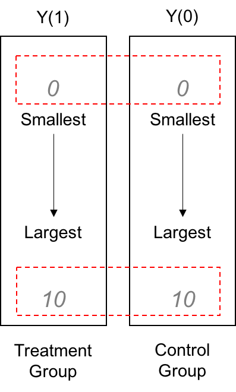

Figure 1: Largest Covariance Estimate

$\widehat{Cov[Y_i(1),Y_i(0)]}$ is smallest if we pair the smallest $Y_i(1)$ values with the largest $Y_i(0)$ values, and the largest $Y_i(1)$ values with the smallest $Y_i(0)$ values. This can be done if we estimate covariance between outcomes when the control group is arranged in ascending order and the treatment group in descending order. Call this $\widehat{Cov_{\text{min}}}[Y_i(1),Y_i(0)]$

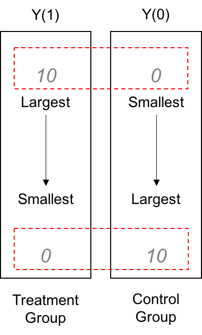

Figure 2: Smallest Covariance Estimate

Then we have two bounds:

Upper bound: $\widehat{Var[Y_i(1)]} + \widehat{Var[Y_i(0)]} - 2\cdot \widehat{Cov_{min}[Y_i(1),Y_i(0)]}$

Lower bound: $\widehat{Var[Y_i(1)]} + \widehat{Var[Y_i(0)]} - 2\cdot \widehat{Cov_{max}[Y_i(1),Y_i(0)]}$

### Empirical Illustration:

Let’s create some data to work with. The data generating process has been specified such that $Var[Y_i(1)] = Var[Y_i(0)]$.

```r
library(tidyverse)
library(kableExtra)
library(fabricatr)
library(estimatr)
library(randomizr)

# Setup: Create some data using "fabricatr"
set.seed(46)
dat1 <- fabricate(
  N = 1000,
  X1 = rnorm(N),
  X2 = rnorm(N),
  Y0 = rnorm(N, mean = 0, sd = 4) + X1 + X2,
  Y1 = Y0 + 5,
  Z = complete_ra(N),
  Y = Y0 * (1 - Z) + Y1 * Z
) %>%
  select(Y1,Y0,Z,Y)

kbl(head(dat1), caption = "Example Dataset") %>%
  kable_classic()
```

Example Dataset

| Y1 | Y0 | Z | Y |
| --- | --- | --- | --- |
| 4.447454 | -0.5525463 | 1 | 4.447454 |
| 1.230178 | -3.7698224 | 0 | -3.769822 |
| 5.148751 | 0.1487505 | 1 | 5.148751 |
| 8.171861 | 3.1718613 | 1 | 8.171861 |
| 7.588860 | 2.5888604 | 1 | 7.588860 |
| 1.865207 | -3.1347933 | 0 | -3.134793 |

```r
true.var <- dat1 %>%
  summarise(`Var(Y0)` = var(Y0), `Var(Y1)` = var(Y1))

kbl(true.var, caption = "Variance of Potential Outcomes") %>%
  kable_classic()
```

Variance of Potential Outcomes

| Var(Y0) | Var(Y1) |
| --- | --- |
| 17.89246 | 17.89246 |

**Step 1:** Estimate the variance of outcomes in the treatment group ($\widehat{Var[Y_i(1)]}$), and the variance of outcomes in the control group ($\widehat{Var[Y_i(0)]}$). Then estimate the difference in variances.

*Note:* This is an *estimate* of the true variance (see above), not of potential outcomes.

```r
var.estimates <- dat1 %>% group_by(Z) %>% summarise(Variance = var(Y))

kbl(var.estimates) %>%
  kable_classic()
```

| Z | Variance |
| --- | --- |
| 0 | 17.50400 |
| 1 | 18.31083 |

```r
var.dif <- var.estimates$Variance[2] - var.estimates$Variance[1]

var.dif
```

```
## [1] 0.8068244
```

**Step 2:** Estimate the minimum and maximum values of $\widehat{Cov[Y0,Y1]}$

```r
control.group <- dat1 %>% filter(Z == 0) %>% arrange(Y)

treat.group.hightolow <- dat1 %>% filter(Z == 1) %>% arrange(desc(Y))

treat.group.lowtohigh <- dat1 %>% filter(Z == 1) %>% arrange(Y)

cov.max <- cov(control.group$Y, treat.group.lowtohigh$Y)

cov.max
```

```
## [1] 17.82075
```

```r
cov.min <- cov(control.group$Y, treat.group.hightolow$Y)

cov.min
```

```
## [1] -17.82226
```

**Step 3:** Estimate the upper and lower bound for $Var[\tau_i]$

```r
var.lower <- var.estimates$Variance[2] + var.estimates$Variance[1] - 2*cov.max

var.lower
```

```
## [1] 0.1733293
```

```r
var.upper <- var.estimates$Variance[2] + var.estimates$Variance[1] - 2*cov.min

var.upper
```

```
## [1] 71.45935
```

So we end up with an interval estimate: $Var[\tau_i] \in [0.17, 71.45]$. Note that $Var[\tau_i] \geq 0$, so the minimum value any lower bound can ever take is 0.

## Difference in Variances

A second way to test for heterogeneity is to evaluate the hypothesis $H_a: \widehat{Var[\tau_i]} \neq 0$. As I will show below, rejecting the hypothesis $Var[Y_i(1)] = Var[Y_i(0)]$ also means rejecting the hypothesis $Var[\tau_i] = 0$. To see this, let’s start with writing the variance of the treated potential outcome as a function of $Y_i(0)$ and $\tau_i$:

$$\begin{equation}
Var[Y_i(1)] = Var[Y_i(0) + \tau_i] = Var[Y_i(0)] + Var[\tau_i] + 2\cdot
Cov[Y_i(0),\tau_i]
\end{equation}$$

Under the constant effects assumption, $Var[\tau_i] = 0$ **and**:

$2 \cdot Cov[Y_i(0), \tau_i] = 0$ because $\tau_i = \tau \forall i$ (i.e. $\tau_i$ is a constant, and the covariance between a random variable and a constant is zero).

This means under the null hypothesis of constant treatment effects:

$Var[Y_i(1)] = Var[Y_i(0)]$ and $Var[Y_i(1)] - Var[Y_i(0)] = 0$

This motivates a test where we use the observed data in the treatment and control groups.

The strategy has the following steps:

**Step 1**: Estimate the difference in variances or $\widehat{Var[Y_i(1)]} - \widehat{Var[Y_i(0)]}$.

**Step 2**: Assuming constant effects, construct a potential outcomes table. Under this null hypothesis: $Var[\tau_i] = 0$ and $Var[Y_i(1)] = Var[Y_i(0)]$

**Step 3**: Conduct randomization inference to get the $p$ value for the observed difference-in-variance. In other words, the probability of obtaining the observed value or more extreme, given the null hypothesis is correct.

If $p \geq \alpha$ (some arbitrarily selected critical value), we cannot reject the null hypothesis $Var[\tau_i] = 0$ and $Var[Y_i(1)] = Var[Y_i(0)]$. This means we cannot rule out constant treatment effects (or lack of heterogeneity).

### Empirical Illustration:

Using the same data as above, let’s conduct this test.

**Step 1:** Estimate the difference in variances: $\widehat{Var[Y1]} - \widehat{Var[Y0]}$ [already done above]

```r
var.dif
```

```
## [1] 0.8068244
```

**Step 2:** Create a schedule of potential outcomes under the constant treatment effects assumption. In other words, if $y_i$ is the observed outcome and $\widehat{E[\tau_i]}$ is the ATE estimate:

For the control group, $Y_i(0) = y_i$ and $Y_i(1) = y_i + \widehat{E[\tau_i]}$.

For the treatment group, $Y_i(1) = y_i$ and $Y_i(0) = y_i - \widehat{E[\tau_i]}$.

```r
ate_hat <- lm_robust(Y ~ Z, data = dat1)$coefficients[2]
ate_hat
```

```
##        Z
## 5.109002
```

```r
ri.data <- dat1 %>%
  select(Y, Z) %>%
  mutate(Y0_hyp = Y - ate_hat * Z,
         Y1_hyp = Y0_hyp + ate_hat)


kbl(head(ri.data)) %>%
  kable_classic()
```

| Y | Z | Y0_hyp | Y1_hyp |
| --- | --- | --- | --- |
| 4.447454 | 1 | -0.6615480 | 4.447454 |
| -3.769822 | 0 | -3.7698224 | 1.339179 |
| 5.148751 | 1 | 0.0397487 | 5.148751 |
| 8.171861 | 1 | 3.0628596 | 8.171861 |
| 7.588860 | 1 | 2.4798587 | 7.588860 |
| -3.134793 | 0 | -3.1347933 | 1.974208 |

**Step 3:** Conduct randomization inference by specifying the design in `declare_ra()`, then drawing random assignment vectors and estimating the difference in variances using the potential outcomes created above.

```r
declaration <- declare_ra(N = 1000, m = 500)

# Step 3A: Write a function that estimates difference in variance

dif_in_var <- function(data) {
  output <- var(data$Y1_hyp[data$Z == 1]) - var(data$Y0_hyp[data$Z == 0])
  return(output)
}

dif_in_var(ri.data)
```

```
## [1] 0.8068244
```

```r
# Step 3B: Conduct randomization inference using "ri2"

library(ri2)

ri.out1 <- conduct_ri(
  test_function = dif_in_var,
  assignment = "Z",
  declaration = declaration,
  data = ri.data,
  sims = 10000
)

summary(ri.out1)
```

```
##                    term  estimate two_tailed_p_value
## 1 Custom Test Statistic 0.8068244             0.6084
```

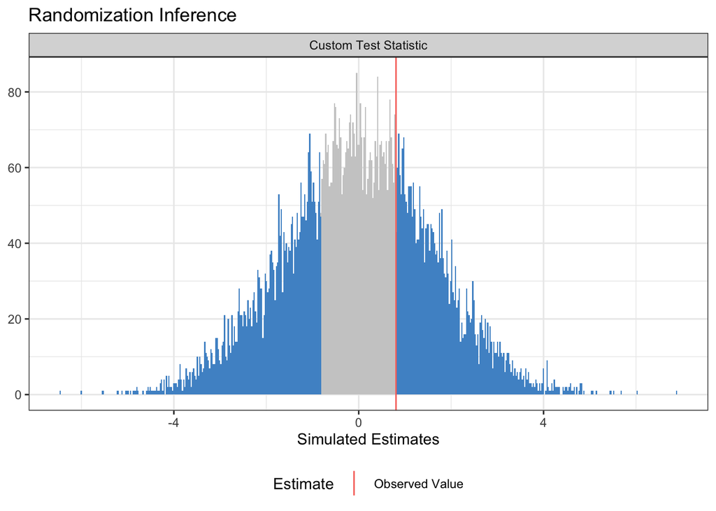

```r
plot(ri.out1)
```

As the hypothesis test reveals, $p = 0.61$ which suggests a high level of congruence between the null hypothesis ($Var[\tau_i] = 0$, or $Var[Y_i(1)] = Var[Y_i(0)]$) and the observed test statistic ($\widehat{Var[Y_i(1)]} - \widehat{Var[Y_i(0)]}$). We fail to reject the null of constant treatment effects. This is in line with our expectations, given the data generating process specified for this empirical case.

# Treatment-by-Covariate Interactions

> An interaction effect refers to the change in treatment effect in different subgroups or covariate profiles. For example, let a covariate $X_i$ take on two values: 0 and 1. In a given sample of subjects, there are two sub-groups: study participants with $X_i=1$ and those with $X_i=0$. An interaction effect refers to the fact that the treatment effect for sub-group $X_i=1$ (or $\widehat{ATE_{X=1}}$) is different from the treatment effect for the sub-group $X_i=0$ (or $\widehat{ATE_{X=0}}$). The ATEs for a particular subset or subgroup of subjects is referred to as a **conditional average treatment effect** or **CATE**.

When we think about CATEs, it is worth pointing out that they are *descriptive* findings. They are not the *causal effect* of a covariate $X_i$ because we do not randomly assign values of $X_i$. Any number of factors can be correlated with $X_i$ that account for differences in the treatment effect.

## Empirical Illustration

Lets create some data in which the treatment effect interacts with a covariate, $X_i \in \{0,1\}$. Specifically,`Y1 = Y0 + 0.5 + 0.25X`.

```r
set.seed(04012024)

# Specify potential outcomes that are unobserved

dat_cov_interaction <- tibble(
  X = complete_ra(N = 500, m = 250),
  U = rnorm(500, mean = 2, sd = 2.5),
  Y0 = rnorm(500, mean = 0 , sd = 2.5) + U * X,
  Y1 = Y0 + 0.5 + 0.25*X
)

dat_cov_interaction <- dat_cov_interaction %>%
  mutate(Z = complete_ra(N = 500, m = 250), # 250 of 500 subjects assigned to treatment
         Y = Y0 * (1 - Z) + Z * Y1)

# Select the observed variables

actual_dat <- dat_cov_interaction %>%
  select(Y,Z,X)

write_csv(actual_dat, file = "covariate_treatment_interaction.csv")

kbl(head(actual_dat), caption = "Example Dataset: Treatment Effect Varies by X", digits = 3) %>%
  kable_classic()
```

Example Dataset: Treatment Effect Varies by X

| Y | Z | X |
| --- | --- | --- |
| 0.528 | 1 | 0 |
| 3.618 | 1 | 0 |
| -2.805 | 1 | 0 |
| -1.200 | 0 | 0 |
| 0.171 | 0 | 1 |
| 2.624 | 0 | 1 |

**Step 1:** Calculate the average treatment effect for the two subgroups, $\widehat{ATE_{X=1}}$ and $\widehat{ATE_{X=0}}$. These are called **conditional average treatment effects**:

```r
cates <- actual_dat %>%
  group_by(X) %>%
  summarise(tidy(difference_in_means(Y ~ Z, data = cur_data()))) %>%
  select(-df, -outcome)

kable(cates,
      caption = "Conditional Average Treatment Effects",
      caption.above = TRUE,
      digits = 2)
```

Conditional Average Treatment Effects

| X | term | estimate | std.error | statistic | p.value | conf.low | conf.high |
| --- | --- | --- | --- | --- | --- | --- | --- |
| 0 | Z | 0.90 | 0.30 | 3.01 | 0.00 | 0.31 | 1.49 |
| 1 | Z | 0.79 | 0.45 | 1.76 | 0.08 | -0.09 | 1.67 |

And here is a coefficient plot made with `ggplot2` that visualizes the same information:

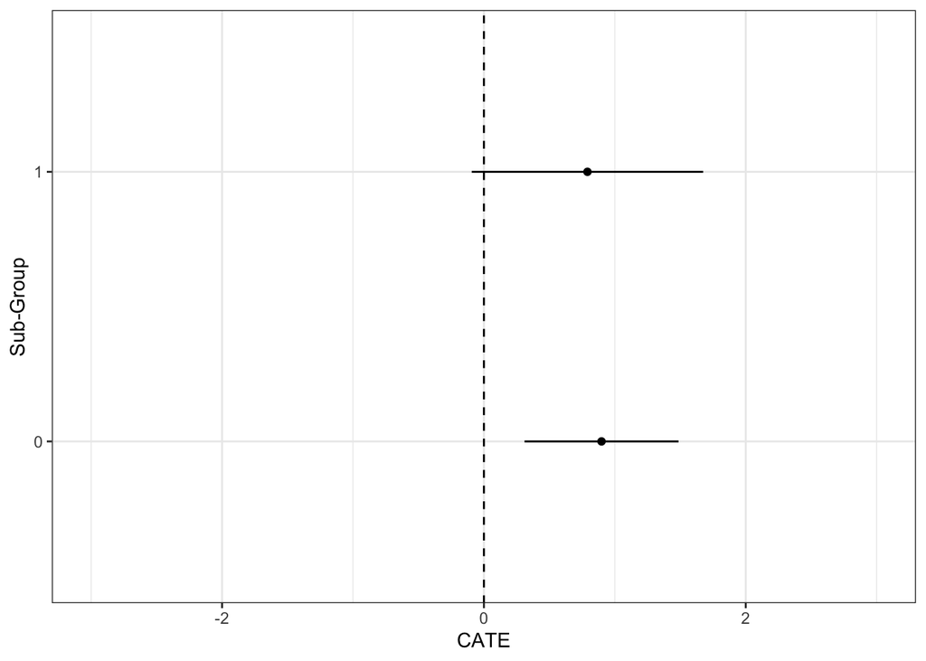

```r
fig_cates <- ggplot(data = cates %>% filter(term != "(Intercept)"),
                    aes(x = estimate, y = as.factor(X))) +
  geom_point() +
  geom_linerange(aes(xmin = conf.low, xmax = conf.high)) +
  geom_vline(xintercept = 0, linetype = "dashed") +
  xlim(-3, 3) +
  xlab("CATE") +
  ylab("Sub-Group") +
  theme_bw()

fig_cates
```

### Exercise

> Load the data set `covariate_treatment_interaction.csv` and evaluate the hypothesis that $\widehat{ATE_{X=1}} - \widehat{ATE_{X=0}} \neq 0$. In other words, the treatment effect in sub-group $X_i=1$ is not equal to the treatment effect in sub-group $X_i=0$.

**Hint:** You should specify a regression of the following type:

$$\begin{equation}
\text{Outcome} = \beta_0 + \beta_1\cdot(Treatment) +
\beta_2\cdot(Covariate) + \beta_3\cdot(Treatment \times Covariate)
\end{equation}$$

We are interested in $\beta_3$ or the difference in conditional average treatment effects.

**Extra:** Can you use the information in the table titled `Conditional Average Treatment Effects` to calculate $\beta_1$ and $\beta_3$? Confirm your calculations with the regression output.

# Treatment-by-Treatment Interactions

> A treatment-by-treatment interaction refers to a design in which subjects are randomly assigned to two treatments, $Z_1$ and $Z_2$. In effect, subjects can be assigned to one of four possible conditions: when both $Z_1$ and $Z_2$ are 0, when both $Z_1$ and $Z_2$ are 1, and when one of the two treatment conditions is equal to 1. A **factorial design** is a generalization of this in which $k$ treatment are randomly assigned, producing $2^k$ experimental conditions (assuming every treatment has 2 levels).

To estimate treatment-by-treatment interaction effects, we specify the following regression:

$$\begin{equation}
\text{Outcome} = \beta_0 + \beta_1Z_1 + \beta_2Z_2 + \beta_3(Z_1 \times
Z_2)
\end{equation}$$

Where $Z_1$ is an indicator variable that takes a value of 1 if the subject receives treatment 1, otherwise 0; and $Z_2$ is an indicator variable that takes a value of 1 if the subject receives treatment 2, otherwise 0. As before, $\beta_3$ captures the difference in treatment effects, i.e. $\widehat{ATE_{Z_2}} - \widehat{ATE_{Z_1}}$.

**Note** that this interaction effect *is* causal because we randomly assign subjects to both treatment conditions, namely $Z_1$ and $Z_2$. In other words, if $\beta_3$ is positive, we can say that treatment $Z_2$ *causes* the effect of $Z_1$ to increase.

## Empirical Illustration

We go back to Bertrand and Mullainathan (2004)’s study that sends resumes to firms for a job opening, randomly varying the applicant’s name (perceptions of race) and “quality” of the resume. They conduct the study in two cities, Boston and Chicago. The outcome of interest is whether the resume gets a call back. Here is a table that reproduces the results in the paper, i.e. the call back rates by treatment conditions (`race` and `quality`) and the covariate `city`.

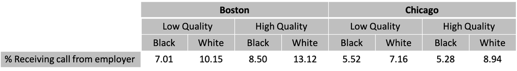

Figure 1: Bertrand and Mullainathan (2004) Results

1. Propose a regression model that assesses the effects of treatments (`race` and `quality`), interaction between them, and interactions between the treatments and the covariate, `city`. Let `black = 1` if the resume uses a name that cues Black identity, `low = 1` if the resume is of low quality, and `boston = 1` for Boston.
2. Use the table above to estimate the parameters of that regression model.

**Extra:** Can you use confirm your calculations by estimating the regression using the Bertrand and Mullainathan (2004) data set we used in a prior week’s problem set?

# Multiple Comparisons

One of the central issues with sub-group analysis is the potential for multiple comparisons bias. Say you run a single test for heterogeneous effects, and decide to reject the null hypothesis if the p value is less than $\alpha = 0.05$. The probability of a false positive in this test is 5%. The probability that you *don’t* have a false positive is $1 - \alpha = 0.95$. Now, say you run a second test. What is the probability that both tests are *not* a false positive? It is $(1-\alpha) \times (1-\alpha) = 0.95^2 = 0.9025$. Which means the probability that atleast one of the tests is a false positive is $1 - (1-0.05)^2 = 0.0975$ or 9.75%. To generalize this for $k$ tests with a $\alpha$ threshold:

$$\begin{equation}
1 - (1 - \alpha)^k
\end{equation}$$

Consider the implications for sub-group analysis: if you conduct $k=20$ tests, the probability that at least one of them is a false positive is $1 - (1 - 0.05)^20 = 0.64$ or 64%!

To address this, we can adopt two “corrections” to p-values that restore the false-positive rate to the original threshold ($\alpha = 0.05$).

## Bonferroni Correction

> Say you run $k$ tests producing p-values $p_1,p_2,\cdots,p_k$, and you want a false-positive rate of $\alpha$, then adjust the threshold to $\frac{\alpha}{k}$ and reject the null hypothesis if $p_i \leq \frac{\alpha}{k}$. Another way to say that is to multiply each p-value by the number of tests $k$ and reject the null hypothesis if $p_i \cdot k \leq \alpha$.

## Benjamini-Hochberg Procedure

> Say you run $k$ tests producing $p$-values $p_1, p_2, \dots, p_k$, and you want to control the false discovery rate at level $\alpha$. Arrange the $p$-values in ascending order, $p_{(1)} \le p_{(2)} \le \cdots \le p_{(k)}$. Find the largest $i$ such that $p_{(i)} \le \frac{i}{k}\alpha$, and reject the null hypotheses corresponding to $p_{(1)}, \dots, p_{(i)}$, including any that failed their own comparison. If no $i$ satisfies the condition, reject nothing. For example, if $p_{(4)} \le \frac{4}{k}\alpha$ but $p_{(3)} > \frac{3}{k}\alpha$, you still reject the hypotheses for $p_{(1)}$ through $p_{(4)}$.

| $i$ | $p_{(i)}$ | $\frac{i}{k}\alpha$ | $p_{(i)} \le \frac{i}{k}\alpha$? |
| --- | --- | --- | --- |
| 1 | 0.001 | 0.005 | Yes |
| 2 | 0.008 | 0.010 | Yes |
| 3 | 0.018 | 0.015 | **No** |
| 4 | 0.019 | 0.020 | Yes |
| 5 | 0.042 | 0.025 | No |
| 6 | 0.060 | 0.030 | No |
| 7 | 0.074 | 0.035 | No |
| 8 | 0.205 | 0.040 | No |
| 9 | 0.212 | 0.045 | No |
| 10 | 0.216 | 0.050 | No |

The largest passing index is $i = 4$, so we reject hypotheses 1 through 4. That includes hypothesis 3, even though $p_{(3)} > \frac{3}{10}\alpha$.

# Solutions

## Exercise I

```r
library(estimatr)
library(texreg)

dat <- read_csv("covariate_treatment_interaction.csv")

fit = lm_robust(Y ~ Z + X + Z:X, data = dat)

htmlreg(
  list(fit),
  include.ci = FALSE,
  digits = 2,
  caption = "CATE Estimates",
  booktabs = TRUE
)
```

CATE Estimates

|  | Model 1 |
| --- | --- |
| (Intercept) | -0.34 |
|  | (0.20) |
| Z | 0.90** |
|  | (0.30) |
| X | 2.31*** |
|  | (0.37) |
| Z:X | -0.11 |
|  | (0.54) |
| R<sup>2</sup> | 0.13 |
| Adj. R<sup>2</sup> | 0.13 |
| Num. obs. | 500 |
| RMSE | 3.02 |

***p < 0.001; **p < 0.01; *p < 0.05

**Takeaway:** The regression table reports $\beta_3$ as `Z:X` or the **interaction effect**. This term captures the difference in CATEs, or $\widehat{ATE_{X=1}} - \widehat{ATE_{X=0}}$. In the table we see that this difference is negative but we cannot reject the null hypothesis $H_0: \beta_3 =0$. In other words, we cannot rule out the possibility that the treatment effect is the same for both sub-groups. This means there is no empirical support for the claim that the treatment “works” for sub-group $X=1$ and does not for sub-group $X=0$; or a version of this claim that treatment effects are “driven” by the sub-group $X=1$.

## Exercise II

1. The regression model can have the following specification:

$$\begin{equation}
\text{Call Back} \sim b_0 + b_1(\text{Black}_i) + b_2(\text{Low}_i) +
b_3(\text{Boston}_i) \\
+ b_4(\text{Black}_i \times \text{Low}_i) + b_5(\text{Black}_i \times
\text{Boston}_i) \\
+ b_6(\text{Low}_i \times \text{Boston}_i) \\
+ b_7(\text{Black}_i \times \text{Low}_i \times \text{Boston}_i)
\end{equation}$$

2. The parameter estimates are:

$\beta_0 = 8.94$, because the reference group is White, “high” quality resume in Chicago.

$\beta_1 = -3.66$, because racial differences in call back rates among high quality resumes in Chicago is $5.28 - 8.94 = -3.66$

$\beta_2 = -1.78$, because resume quality-based differences in call back rates among White applicants in Chicago is $7.16 - 8.94 = -1.78$

$\beta_3 = 4.18$, because the difference in call back rates between Boston and Chicago among high quality resumes of White applicants is $13.12 - 8.94 = 4.18$

$\beta_4 = 2.02$, because $(5.52 - 7.16) - (5.28 - 8.94) = 2.02$

$\beta_5 = -0.96$, because $(8.50 - 13.12) - (5.28 - 8.94) = -0.96$

$\beta_6 = -1.19$, because $(10.15 - 13.12) - (7.16 - 8.94) = -1.19$

$\beta_7 = -0.54$, because $[(7.01 - 10.15) - (8.50 - 13.12)] - [(5.52 - 7.16) - (5.28 - 8.94)] = -0.54$